# Prosper Loan Data - Communicate Findings

## by Ayodeji Arowolo

## Investigation Overview

> The essence of the investigation into the Prosper loan data is to be able to predict borrower APR based on some provided loan information. The focus of my analysis is on Loan amount, Term, Year, Employee Status, Stated Income, Debt to Income Ratio, Occupation etc.

## Dataset Overview

> The dataset (loan_df) conatins 84,853 entries and 19 columns across the loan and borrowers information. There are numeric and qualitative data in the dataset. The prosper rating, Borrower APR, loan amount are some of the very important columns in the data.

## The Distribution of the Loans by period (Year and Month)

> Loans grew from year **2009 till 2013**, where it reached its peak. There was a decline between *2013 and 2014*

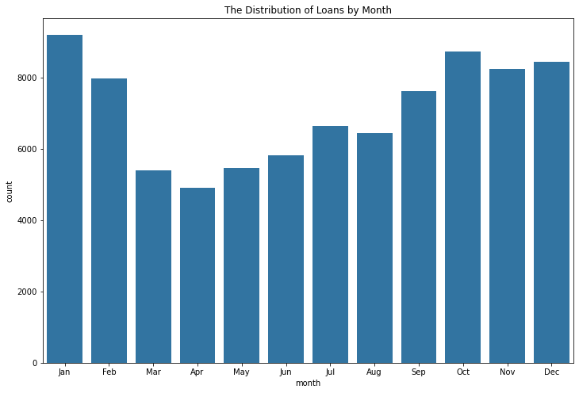

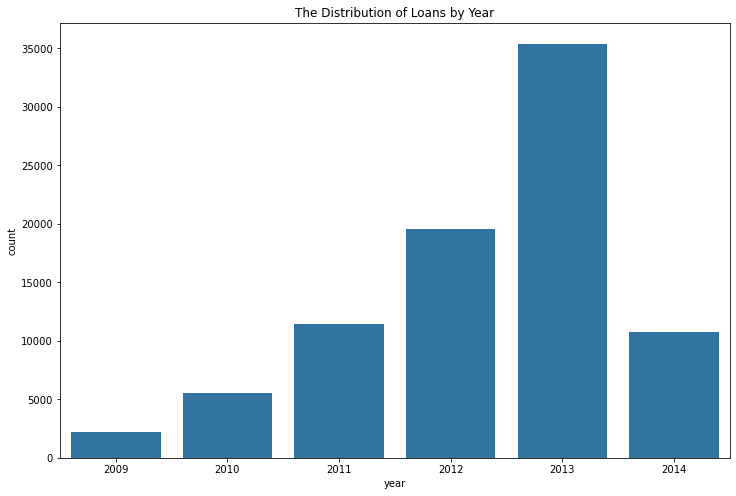

## The Distribution of the Loans by Debt To Income Ratio

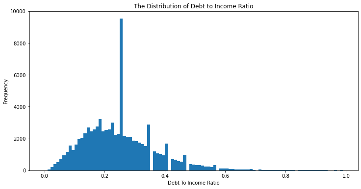

## The distribution of Borrower APR by Loan Amount

Overall, the Borrower APR decreases with a higher loan amount.

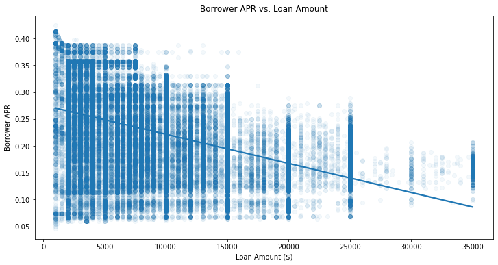

## The Distribution of year, borrower rate and being a home owner

Home owners can access loans at cheaper rates compared to non home owners. The gap between the rates applicable to home owners and non home owners reduced between 2009 and 2011.

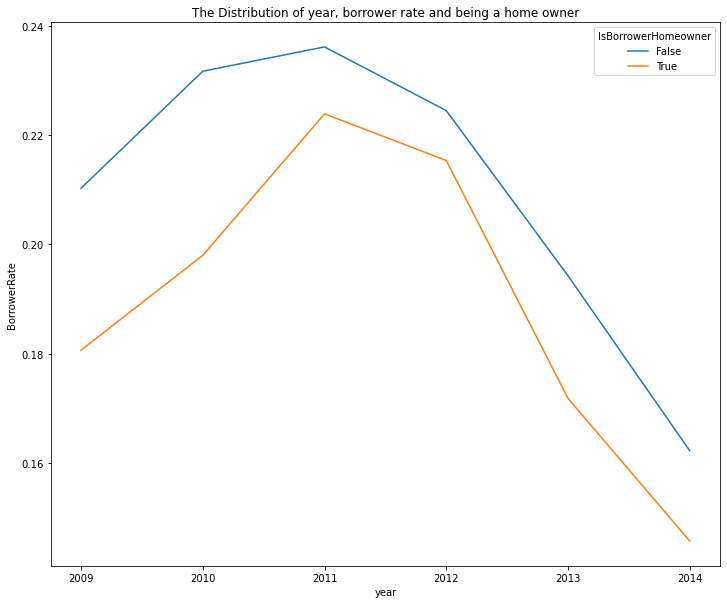

## The Distribution between Prosper Rating and Borrower Rate

Good Prosper Ratings translate to lower borrowing rates. The best rated borrowers can borrow at below 10% APR, while the borrowers with the least ratings can be charged as much as 35% APR.

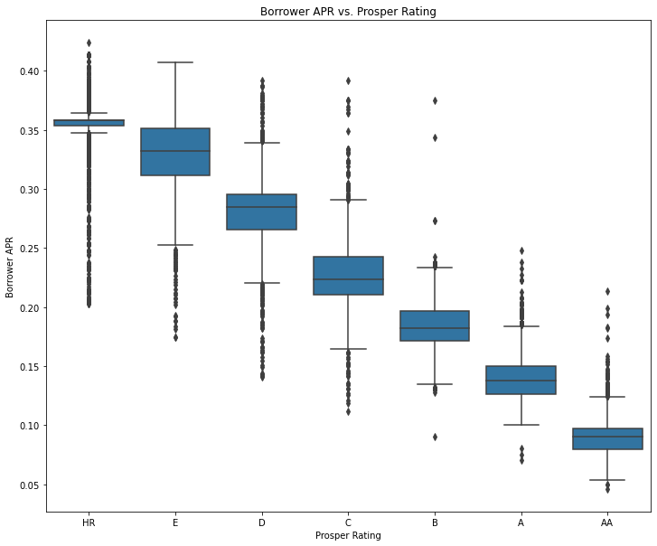

## The Effect of Prosper Rating on Loan amount and APR

Generally, loan amount accessible to borrowers increases with improved ratings. A working theory for most loan algorithms is that a borrower's rating improves as he or she takes loans and repays them. Also, borrower APR reduces with improved Prosper rating. Finally, the loan amount inversely varies with the APR for most prosper ratings. For the highly rated borrowers, the reverse is the case as the institution can make more profit from such borrowers.

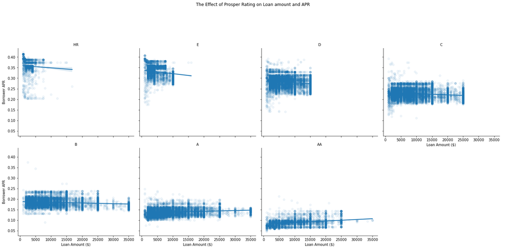